# Презентация по лабораторной работе номер 7

Основы информационной безопасности

Татьяна Александровна Пономарева

Российский университет дружбы народов

2026-04-15

# Информация

## Докладчик

- Пономарева Татьяна Александровна
- Студент группы НКАбд-04-24
- Российский университет дружбы народов им. П. Лумумбы
- taponomareva6742@gmail.com
- https://github.com/taponomareva

# Вводная часть

## Цель работы

Освоить на практике применение режима однократного гаммирования

## Задание

Разработать приложение, позволяющее шифровать и дешифровать данные в режиме однократного кодирования

## Теоретическое введение

Гаммирование – это наложение (снятие) на открытые (зашифрованные) данные криптографической гаммы, то есть последовательности элементов данных, вырабатываемых с помощью некоторого криптографического алгоритма, для получения зашифрованных (открытых) данных.

С точки зрения теории криптоанализа, метод шифрования случайной однократной равновероятной гаммой той же длины, что и открытый текст, является невскрываемым. Кроме того, даже раскрыв часть сообщения, дешифровщик не сможет хоть сколько-нибудь поправить положение – информация о вскрытом участке гаммы не дает информации об остальных ее частях. “Наложение” гаммы не что иное, как выполнение операции сложения по модулю 2 [1].

# Выполнение лабораторной работы

## Создание файла lab7.py и его содержимое

Создаем файл lab7.py и пишем код на языке Python для выполнения задания (рис. 1).

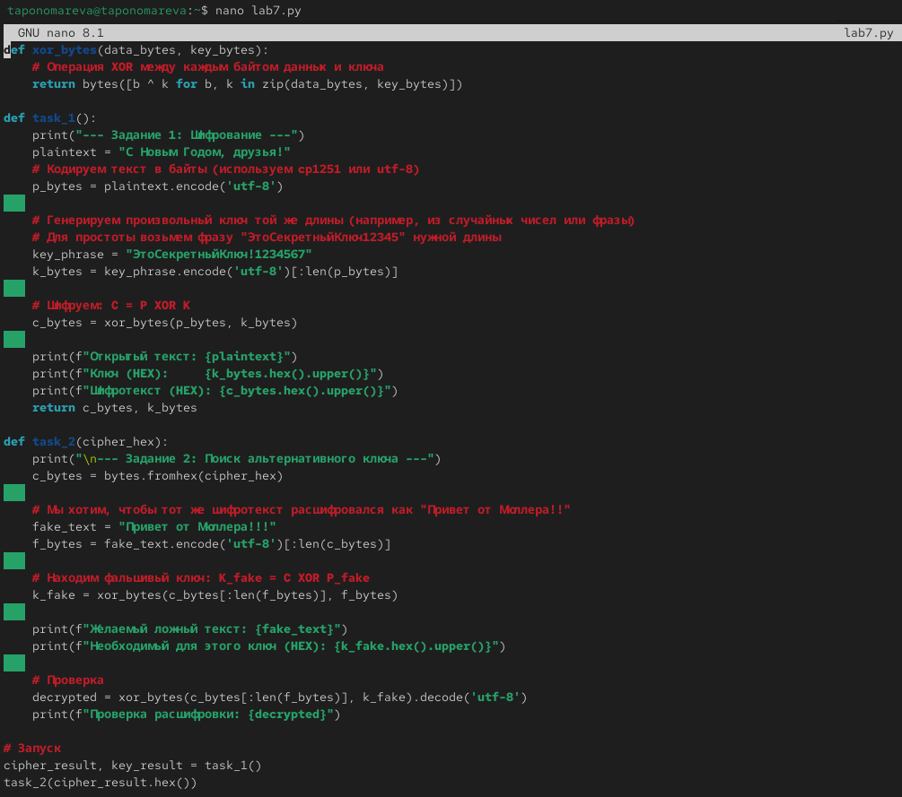

Рисунок 1: Создание файла lab7.py и его содержимое

## Запуск lab7.py

Запускаем файл lab7.py (рис. 2).

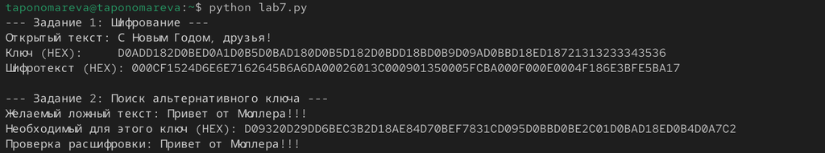

Рисунок 2: Запуск lab7.py

# Выводы

В ходе выполнения лабораторной работы применение режима однократного гаммирования было освоено на практике

# Список литературы

1. StudFiles. Режим шифрования однократного гаммирования: Программные средства защиты информации [Электронный ресурс]. НГТУ (Новосибирский государственный технический университет). URL: https://studfile.net/preview/ 11550163/page:15/ (дата обращения: 15.04.2026).